# Homework 1 - Question 4

## Dataset

```python
import os
import random

import numpy as np
import torch
from sklearn.datasets import fetch_openml
from sklearn.model_selection import train_test_split
import time


def configure_seed(seed):
    os.environ["PYTHONHASHSEED"] = str(seed)
    random.seed(seed)
    np.random.seed(seed)
    torch.manual_seed(seed)
    if torch.cuda.is_available():
        torch.cuda.manual_seed(seed)
        torch.backends.cudnn.deterministic = True
        torch.backends.cudnn.benchmark = False


def fetch_classification_data(dataset="Fashion-MNIST", random_state=42):
    """
    Loads the dataset from openml, normalizes feature values (by dividing
    everything by 256), and saves to an npz file.

    dataset: the name of the dataset (accepted: "mnist_784", "Fashion-MNIST")
    """
    assert dataset in {"mnist_784", "Fashion-MNIST"}
    start_time = time.time()
    X, y = fetch_openml(dataset, version=1, return_X_y=True, as_frame=False)
    print("Downloaded data in {:.4f} seconds".format(time.time() - start_time))
    X /= 256  # normalize
    y = y.astype(int)  # fetch_openml loads it as a str
    train_dev_X, train_dev_y = X[:60000], y[:60000]
    train_X, dev_X, train_y, dev_y = train_test_split(
        train_dev_X, train_dev_y, train_size=50000, test_size=10000, random_state=random_state
    )
    test_X, test_y = X[60000:], y[60000:]
    np.savez_compressed(
        dataset + ".npz",
        Xtrain=train_X, ytrain=train_y,
        Xdev=dev_X, ydev=dev_y,
        Xtest=test_X, ytest=test_y
    )


def load_classification_data(bias=False):
    """
    Loads the preprocessed, featurized fashion-mnist dataset from
    Fashion-MNIST.npz, optionally adding a bias feature.
    """
    data = np.load('Fashion-MNIST.npz')
    train_X = data["Xtrain"]
    dev_X = data["Xdev"]
    test_X = data["Xtest"]
    if bias:
        train_X = np.hstack((train_X, np.ones((train_X.shape[0], 1))))
        dev_X = np.hstack((dev_X, np.ones((dev_X.shape[0], 1))))
        test_X = np.hstack((test_X, np.ones((test_X.shape[0], 1))))
    return {"train": (train_X, data["ytrain"]),
            "dev": (dev_X, data["ydev"]),
            "test": (test_X, data["ytest"])}


def load_regression_data(bias=False):
    """
    Loads the preprocessed, featurized Ames housing dataset from ames.npz.
    """
    data = np.load('ames.npz')
    train_X = data["Xtrain"]
    test_X = data["Xtest"]
    train_y = data["ytrain"].reshape(-1)
    test_y = data["ytest"].reshape(-1)
    if bias:
        train_X = np.hstack((train_X, np.ones((train_X.shape[0], 1))))
        test_X = np.hstack((test_X, np.ones((test_X.shape[0], 1))))
    return {"train": (train_X, train_y),
            "test": (test_X, test_y)}


class ClassificationDataset(torch.utils.data.Dataset):

    def __init__(self, data):
        """
        data: the dict returned by utils.load_classification_data
        """
        train_X, train_y = data["train"]
        dev_X, dev_y = data["dev"]
        test_X, test_y = data["test"]

        self.X = torch.tensor(train_X, dtype=torch.float32)
        self.y = torch.tensor(train_y, dtype=torch.long)

        self.dev_X = torch.tensor(dev_X, dtype=torch.float32)
        self.dev_y = torch.tensor(dev_y, dtype=torch.long)

        self.test_X = torch.tensor(test_X, dtype=torch.float32)
        self.test_y = torch.tensor(test_y, dtype=torch.long)

    def __len__(self):
        return len(self.X)

    def __getitem__(self, idx):
        return self.X[idx], self.y[idx]
```

## (a)

Implement a linear model with logistic regression, using stochastic gradient descent as your training algorithm (use a batch size of 1). Train your model for `20 epochs` and tune the learning rate on your validation data, using the following values: `{0.001, 0.01, 0.1}`. For the best configuration, report it and plot two things: the training loss and the validation accuracy, both as a function of the epoch number. Report the final accuracy on the test set. In the skeleton code, you will need to implement the method `train_batch()` and the class LogisticRegression’s `__init__()` and `forward()` methods.

```python
import argparse

import torch
from torch.utils.data import DataLoader
import torch.nn as nn
from matplotlib import pyplot as plt

import utils
```

```python
# Q3.1
class LogisticRegression(nn.Module):

    def __init__(self, n_classes, n_features, **kwargs):
        """
        n_classes (int)
        n_features (int)

        The __init__ should be used to declare what kind of layers and other
        parameters the module has. For example, a logistic regression module
        has a weight matrix and bias vector. For an idea of how to use
        pytorch to make weights and biases, have a look at
        https://pytorch.org/docs/stable/nn.html
        """
        super().__init__()
        # In a pytorch module, the declarations of layers needs to come after
        # the super __init__ line, otherwise the magic doesn't work.

        # Linear layer to compute logits
        self.layer = nn.Linear(n_features, n_classes)

    def forward(self, x, **kwargs):
        """
        x (batch_size x n_features): a batch of training examples

        Every subclass of nn.Module needs to have a forward() method. forward()
        describes how the module computes the forward pass. In a log-lineear
        model like this, for example, forward() needs to compute the logits
        y = Wx + b, and return y (you don't need to worry about taking the
        softmax of y because nn.CrossEntropyLoss does that for you).

        One nice thing about pytorch is that you only need to define the
        forward pass -- this is enough for it to figure out how to do the
        backward pass.
        """
        output = self.layer(x)
        return output
```

```python
def train_batch(X, y, model, optimizer, criterion, **kwargs):
    """
    X (n_examples x n_features)
    y (n_examples): gold labels
    model: a PyTorch defined model
    optimizer: optimizer used in gradient step
    criterion: loss function

    To train a batch, the model needs to predict outputs for X, compute the
    loss between these predictions and the "gold" labels y using the criterion,
    and compute the gradient of the loss with respect to the model parameters.

    Check out https://pytorch.org/docs/stable/optim.html for examples of how
    to use an optimizer object to update the parameters.

    This function should return the loss (tip: call loss.item()) to get the
    loss as a numerical value that is not part of the computation graph.
    """
    # tell Pytorch we are training the model
    model.train()

    # zero the parameter gradients
    optimizer.zero_grad()

    # forward pass
    outputs = model(X)

    # compute the loss
    loss = criterion(outputs, y)

    # backward (training phase)
    loss.backward()

    # optimize parameters
    optimizer.step()

    return loss.item()
```

```python
def predict(model, X):
    """X (n_examples x n_features)"""
    scores = model(X)  # (n_examples x n_classes)
    predicted_labels = scores.argmax(dim=-1)  # (n_examples)
    return predicted_labels
```

```python
def evaluate(model, X, y):
    """
    X (n_examples x n_features)
    y (n_examples): gold labels
    """
    model.eval()
    y_hat = predict(model, X)
    n_correct = (y == y_hat).sum().item()
    n_possible = float(y.shape[0])
    model.train()
    return n_correct / n_possible
```

```python
def plot(epochs, plottable, ylabel='', name=''):
    plt.clf()
    plt.xlabel('Epoch')
    plt.ylabel(ylabel)
    plt.plot(epochs, plottable)
    plt.savefig('%s.pdf' % (name), bbox_inches='tight')
```

```python
def main(model = 'logistic_regression', epochs = 20, batch_size = 1, learning_rate = 0.01, l2_decay = 0,
         hidden_sizes = 200, layers = 1, dropout = 0.3, activation = 'relu', optimizer = 'sgd'):

    configure_seed(seed=42)

    data = load_classification_data()
    dataset = ClassificationDataset(data)
    train_dataloader = DataLoader(
        dataset, batch_size = batch_size, shuffle=True)

    dev_X, dev_y = dataset.dev_X, dataset.dev_y
    test_X, test_y = dataset.test_X, dataset.test_y

    n_classes = torch.unique(dataset.y).shape[0]  # 10
    n_feats = dataset.X.shape[1]

    # initialize the model
    if model == 'logistic_regression':
        model = LogisticRegression(n_classes, n_feats)
    else:
        model = FeedforwardNetwork(
            n_classes, n_feats,
            hidden_sizes, layers,
            activation, dropout)

    # get an optimizer
    optims = {"adam": torch.optim.Adam, "sgd": torch.optim.SGD}

    optim_cls = optims[optimizer]
    optimizer = optim_cls(
        model.parameters(),
        lr=learning_rate,
        weight_decay=l2_decay)

    # get a loss criterion
    criterion = nn.CrossEntropyLoss()

    # get device
    # device = torch.device("cuda:0" if torch.cuda.is_available() else "cpu")
    # send model to device
    # model = model.to(device)

    # training loop
    epochs = torch.arange(1, epochs + 1)
    train_mean_losses = []
    valid_accs = []
    train_losses = []
    for ii in epochs:
        print('Training epoch {}'.format(ii))
        for X_batch, y_batch in train_dataloader:
            # X_batch = X_batch.to(device)
            # y_batch = y_batch.to(device)
            loss = train_batch(
                X_batch, y_batch, model, optimizer, criterion)
            train_losses.append(loss)

        mean_loss = torch.tensor(train_losses).mean().item()
        print('Training loss: %.4f' % (mean_loss))

        train_mean_losses.append(mean_loss)
        # dev_X = dev_X.to(device)
        # dev_y = dev_y.to(device)
        valid_accs.append(evaluate(model, dev_X, dev_y))
        print('Valid acc: %.4f' % (valid_accs[-1]))

    # test_X = test_X.to(device)
    # test_y = test_y.to(device)
    print('Final Test acc: %.4f' % (evaluate(model, test_X, test_y)))
    # plot
    fig, axs = plt.subplots(2)
    axs[0].plot(epochs, train_mean_losses)
    axs[0].set_xlabel('Epoch')
    axs[0].set_ylabel('Train Loss')
    axs[1].plot(epochs, valid_accs)
    axs[1].set_xlabel('Epoch')
    axs[1].set_ylabel('Val accuracy')
```

### Learning rate = 0.001

```
Training epoch 1
Training loss: 0.6718
Valid acc: 0.8194
Training epoch 2
Training loss: 0.5918
Valid acc: 0.8238
Training epoch 3
Training loss: 0.5540
Valid acc: 0.8348
Training epoch 4
Training loss: 0.5308
Valid acc: 0.8334
Training epoch 5
Training loss: 0.5145
Valid acc: 0.8437
Training epoch 6
Training loss: 0.5022
Valid acc: 0.8444
Training epoch 7
Training loss: 0.4925
Valid acc: 0.8383
Training epoch 8
Training loss: 0.4845
Valid acc: 0.8415
Training epoch 9
Training loss: 0.4778
Valid acc: 0.8401
Training epoch 10
Training loss: 0.4721
Valid acc: 0.8454
Training epoch 11
Training loss: 0.4671
Valid acc: 0.8481
Training epoch 12
Training loss: 0.4628
Valid acc: 0.8480
Training epoch 13
Training loss: 0.4588
Valid acc: 0.8424
Training epoch 14
Training loss: 0.4553
Valid acc: 0.8491
Training epoch 15
Training loss: 0.4522
Valid acc: 0.8481
Training epoch 16
Training loss: 0.4493
Valid acc: 0.8472
Training epoch 17
Training loss: 0.4466
Valid acc: 0.8523
Training epoch 18
Training loss: 0.4441
Valid acc: 0.8516
Training epoch 19
Training loss: 0.4418
Valid acc: 0.8512
Training epoch 20
Training loss: 0.4397
Valid acc: 0.8499
Final Test acc: 0.8388
```

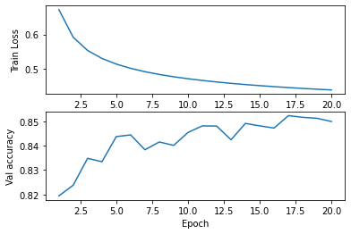

```python
main(model = 'logistic_regression', epochs = 20, batch_size = 1, learning_rate = 0.001, l2_decay = 0,
         hidden_sizes = 200, layers = 1, dropout = 0.3, activation = 'relu', optimizer = 'sgd')
```

**Final test accuracy: 0.8388**

### Learning rate = 0.01

```
Training epoch 1
Training loss: 0.5996
Valid acc: 0.8042
Training epoch 2
Training loss: 0.5645
Valid acc: 0.8166
Training epoch 3
Training loss: 0.5457
Valid acc: 0.8259
Training epoch 4
Training loss: 0.5349
Valid acc: 0.8153
Training epoch 5
Training loss: 0.5267
Valid acc: 0.8291
Training epoch 6
Training loss: 0.5206
Valid acc: 0.8492
Training epoch 7
Training loss: 0.5155
Valid acc: 0.8356
Training epoch 8
Training loss: 0.5110
Valid acc: 0.8475
Training epoch 9
Training loss: 0.5075
Valid acc: 0.8199
Training epoch 10
Training loss: 0.5046
Valid acc: 0.8300
Training epoch 11
Training loss: 0.5017
Valid acc: 0.7746
Training epoch 12
Training loss: 0.4994
Valid acc: 0.8318
Training epoch 13
Training loss: 0.4970
Valid acc: 0.8194
Training epoch 14
Training loss: 0.4951
Valid acc: 0.8198
Training epoch 15
Training loss: 0.4934
Valid acc: 0.8138
Training epoch 16
Training loss: 0.4918
Valid acc: 0.8396
Training epoch 17
Training loss: 0.4903
Valid acc: 0.7916
Training epoch 18
Training loss: 0.4890
Valid acc: 0.8319
Training epoch 19
Training loss: 0.4877
Valid acc: 0.8351
Training epoch 20
Training loss: 0.4866
Valid acc: 0.8405
Final Test acc: 0.8333
```

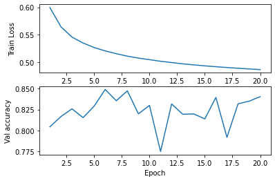

```python
main(model = 'logistic_regression', epochs = 20, batch_size = 1, learning_rate = 0.01, l2_decay = 0,
         hidden_sizes = 200, layers = 1, dropout = 0.3, activation = 'relu', optimizer = 'sgd')
```

**Final test accuracy: 0.8333**

### Learning rate = 0.1

```
Training epoch 1
Training loss: 3.4728
Valid acc: 0.7392
Training epoch 2
Training loss: 3.3731
Valid acc: 0.7958
Training epoch 3
Training loss: 3.3212
Valid acc: 0.8104
Training epoch 4
Training loss: 3.2884
Valid acc: 0.7329
Training epoch 5
Training loss: 3.2607
Valid acc: 0.8102
Training epoch 6
Training loss: 3.2400
Valid acc: 0.8243
Training epoch 7
Training loss: 3.2218
Valid acc: 0.8290
Training epoch 8
Training loss: 3.2028
Valid acc: 0.8264
Training epoch 9
Training loss: 3.1904
Valid acc: 0.7607
Training epoch 10
Training loss: 3.1802
Valid acc: 0.8172
Training epoch 11
Training loss: 3.1686
Valid acc: 0.7266
Training epoch 12
Training loss: 3.1612
Valid acc: 0.7618
Training epoch 13
Training loss: 3.1504
Valid acc: 0.7959
Training epoch 14
Training loss: 3.1453
Valid acc: 0.7855
Training epoch 15
Training loss: 3.1382
Valid acc: 0.7906
Training epoch 16
Training loss: 3.1336
Valid acc: 0.7958
Training epoch 17
Training loss: 3.1290
Valid acc: 0.7782
Training epoch 18
Training loss: 3.1233
Valid acc: 0.7768
Training epoch 19
Training loss: 3.1207
Valid acc: 0.8296
Training epoch 20
Training loss: 3.1164
Valid acc: 0.8053
Final Test acc: 0.7959
```

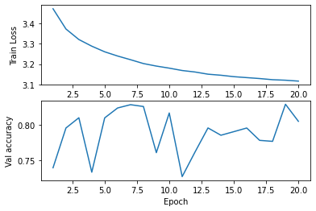

```python
main(model = 'logistic_regression', epochs = 20, batch_size = 1, learning_rate = 0.1, l2_decay = 0,
         hidden_sizes = 200, layers = 1, dropout = 0.3, activation = 'relu', optimizer = 'sgd')
```

**Final test accuracy: 0.7959**

## (b)

Implement a feed-forward neural network with a single layer, using dropout regularization. Make sure to include all the hyperparameters and training/model design choices shown in Table 1. Use the values presented in the table as default. Tune each of these hyperparameters while leaving the remaining at their default value:

- The learning rate: `{0.001, 0.01, 0.1}`.
- The hidden size: `{100, 200}`.
- The dropout probability: `{0.3, 0.5}`.
- The activation function: `relu` and `tanh`.
- The optimizer: `SGD` and `Adam`.

| **Number of Epochs** | 20 |
| --- | --- |
| **Learning Rate** | 0.01 |
| **Hidden Size** | 200 |
| **Dropout** | 0.3 |
| **Batch Size** | 1 |
| **Activation** | ReLU |
| **Optimizer** | SGD |

```python
import argparse

import torch
from torch.utils.data import DataLoader
import torch.nn as nn
from matplotlib import pyplot as plt

import utils
```

```python
# Q3.2
class FeedforwardNetwork(nn.Module):
    def __init__(
            self, n_classes, n_features, hidden_size, layers,
            activation_type, dropout, **kwargs):
        """
        n_classes (int)
        n_features (int)
        hidden_size (int)
        layers (int)
        activation_type (str)
        dropout (float): dropout probability

        As in logistic regression, the __init__ here defines a bunch of
        attributes that each FeedforwardNetwork instance has. Note that nn
        includes modules for several activation functions and dropout as well.
        """
        super().__init__()

        if activation_type == 'relu':
            g = nn.ReLU()
        else:
            g = nn.Tanh()

        # create list of parameters, activations and dropouts
        modules = []

        for i in range(layers + 1):
            if i == 0:
                modules.append(nn.Linear(n_features, hidden_size))
                modules.append(g)
                modules.append(nn.Dropout(dropout))
            elif i == layers:
                modules.append(nn.Linear(hidden_size, n_classes))
            else:
                modules.append(nn.Linear(hidden_size, hidden_size))
                modules.append(g)
                modules.append(nn.Dropout(dropout))

        self.sequential = nn.Sequential(*modules)


    def forward(self, x, **kwargs):
        """
        x (batch_size x n_features): a batch of training examples

        This method needs to perform all the computation needed to compute
        the output logits from x. This will include using various hidden
        layers, pointwise nonlinear functions, and dropout.
        """
        x = self.sequential(x)
        return x
```

```python
def train_batch(X, y, model, optimizer, criterion, **kwargs):
    """
    X (n_examples x n_features)
    y (n_examples): gold labels
    model: a PyTorch defined model
    optimizer: optimizer used in gradient step
    criterion: loss function

    To train a batch, the model needs to predict outputs for X, compute the
    loss between these predictions and the "gold" labels y using the criterion,
    and compute the gradient of the loss with respect to the model parameters.

    Check out https://pytorch.org/docs/stable/optim.html for examples of how
    to use an optimizer object to update the parameters.

    This function should return the loss (tip: call loss.item()) to get the
    loss as a numerical value that is not part of the computation graph.
    """
    # tell Pytorch we are training the model
    model.train()

    # zero the parameter gradients
    optimizer.zero_grad()

    # forward pass
    outputs = model(X)

    # compute the loss
    loss = criterion(outputs, y)

    # backward (training phase)
    loss.backward()

    # optimize parameters
    optimizer.step()

    return loss.item()
```

```python
def predict(model, X):
    """X (n_examples x n_features)"""
    scores = model(X)  # (n_examples x n_classes)
    predicted_labels = scores.argmax(dim=-1)  # (n_examples)
    return predicted_labels
```

```python
def evaluate(model, X, y):
    """
    X (n_examples x n_features)
    y (n_examples): gold labels
    """
    model.eval()
    y_hat = predict(model, X)
    n_correct = (y == y_hat).sum().item()
    n_possible = float(y.shape[0])
    model.train()
    return n_correct / n_possible
```

```python
def plot(epochs, plottable, ylabel='', name=''):
    plt.clf()
    plt.xlabel('Epoch')
    plt.ylabel(ylabel)
    plt.plot(epochs, plottable)
    plt.savefig('%s.pdf' % (name), bbox_inches='tight')
```

```python
def main(model = 'logistic_regression', epochs = 20, batch_size = 1, learning_rate = 0.01, l2_decay = 0,
         hidden_sizes = 200, layers = 1, dropout = 0.3, activation = 'relu', optimizer = 'sgd'):

    configure_seed(seed=42)

    data = load_classification_data()
    dataset = ClassificationDataset(data)
    train_dataloader = DataLoader(
        dataset, batch_size = batch_size, shuffle=True)

    dev_X, dev_y = dataset.dev_X, dataset.dev_y
    test_X, test_y = dataset.test_X, dataset.test_y

    n_classes = torch.unique(dataset.y).shape[0]  # 10
    n_feats = dataset.X.shape[1]

    # initialize the model
    if model == 'logistic_regression':
        model = LogisticRegression(n_classes, n_feats)
    else:
        model = FeedforwardNetwork(
            n_classes, n_feats,
            hidden_sizes, layers,
            activation, dropout)

    # get an optimizer
    optims = {"adam": torch.optim.Adam, "sgd": torch.optim.SGD}

    optim_cls = optims[optimizer]
    optimizer = optim_cls(
        model.parameters(),
        lr=learning_rate,
        weight_decay=l2_decay)

    # get a loss criterion
    criterion = nn.CrossEntropyLoss()

    # get device
    # device = torch.device("cuda:0" if torch.cuda.is_available() else "cpu")
    # send model to device
    # model = model.to(device)

    # training loop
    epochs = torch.arange(1, epochs + 1)
    train_mean_losses = []
    valid_accs = []
    train_losses = []
    for ii in epochs:
        print('Training epoch {}'.format(ii))
        for X_batch, y_batch in train_dataloader:
            # X_batch = X_batch.to(device)
            # y_batch = y_batch.to(device)
            loss = train_batch(
                X_batch, y_batch, model, optimizer, criterion)
            train_losses.append(loss)

        mean_loss = torch.tensor(train_losses).mean().item()
        print('Training loss: %.4f' % (mean_loss))

        train_mean_losses.append(mean_loss)
        # dev_X = dev_X.to(device)
        # dev_y = dev_y.to(device)
        valid_accs.append(evaluate(model, dev_X, dev_y))
        print('Valid acc: %.4f' % (valid_accs[-1]))

    # test_X = test_X.to(device)
    # test_y = test_y.to(device)
    print('Final Test acc: %.4f' % (evaluate(model, test_X, test_y)))
    # plot
    fig, axs = plt.subplots(2)
    axs[0].plot(epochs, train_mean_losses)
    axs[0].set_xlabel('Epoch')
    axs[0].set_ylabel('Train Loss')
    axs[1].plot(epochs, valid_accs)
    axs[1].set_xlabel('Epoch')
    axs[1].set_ylabel('Val accuracy')
```

### Learning rate = 0.001

```
Training epoch 1
Training loss: 0.7346
Valid acc: 0.8254
Training epoch 2
Training loss: 0.6165
Valid acc: 0.8432
Training epoch 3
Training loss: 0.5597
Valid acc: 0.8456
Training epoch 4
Training loss: 0.5244
Valid acc: 0.8565
Training epoch 5
Training loss: 0.4986
Valid acc: 0.8572
Training epoch 6
Training loss: 0.4789
Valid acc: 0.8653
Training epoch 7
Training loss: 0.4632
Valid acc: 0.8693
Training epoch 8
Training loss: 0.4500
Valid acc: 0.8698
Training epoch 9
Training loss: 0.4390
Valid acc: 0.8713
Training epoch 10
Training loss: 0.4293
Valid acc: 0.8769
Training epoch 11
Training loss: 0.4206
Valid acc: 0.8770
Training epoch 12
Training loss: 0.4129
Valid acc: 0.8810
Training epoch 13
Training loss: 0.4056
Valid acc: 0.8813
Training epoch 14
Training loss: 0.3994
Valid acc: 0.8799
Training epoch 15
Training loss: 0.3934
Valid acc: 0.8806
Training epoch 16
Training loss: 0.3879
Valid acc: 0.8821
Training epoch 17
Training loss: 0.3828
Valid acc: 0.8821
Training epoch 18
Training loss: 0.3781
Valid acc: 0.8841
Training epoch 19
Training loss: 0.3735
Valid acc: 0.8859
Training epoch 20
Training loss: 0.3693
Valid acc: 0.8884
Final Test acc: 0.8794
```

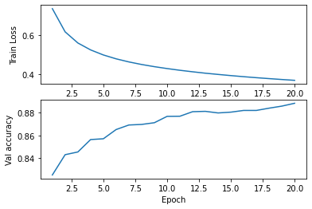

```python
main(model = 'mlp', epochs = 20, batch_size = 1, learning_rate = 0.001, l2_decay = 0,
         hidden_sizes = 200, layers = 1, dropout = 0.3, activation = 'relu', optimizer = 'sgd')
```

**Final test accuracy: 0.8794**

### Learning rate = 0.01

```
Training epoch 1
Training loss: 0.5956
Valid acc: 0.8300
Training epoch 2
Training loss: 0.5363
Valid acc: 0.7986
Training epoch 3
Training loss: 0.5061
Valid acc: 0.8340
Training epoch 4
Training loss: 0.4848
Valid acc: 0.8637
Training epoch 5
Training loss: 0.4691
Valid acc: 0.8475
Training epoch 6
Training loss: 0.4569
Valid acc: 0.8534
Training epoch 7
Training loss: 0.4466
Valid acc: 0.8614
Training epoch 8
Training loss: 0.4376
Valid acc: 0.8620
Training epoch 9
Training loss: 0.4298
Valid acc: 0.8596
Training epoch 10
Training loss: 0.4228
Valid acc: 0.8777
Training epoch 11
Training loss: 0.4164
Valid acc: 0.8686
Training epoch 12
Training loss: 0.4105
Valid acc: 0.8715
Training epoch 13
Training loss: 0.4052
Valid acc: 0.8735
Training epoch 14
Training loss: 0.4002
Valid acc: 0.8753
Training epoch 15
Training loss: 0.3957
Valid acc: 0.8789
Training epoch 16
Training loss: 0.3914
Valid acc: 0.8810
Training epoch 17
Training loss: 0.3873
Valid acc: 0.8748
Training epoch 18
Training loss: 0.3834
Valid acc: 0.8760
Training epoch 19
Training loss: 0.3798
Valid acc: 0.8785
Training epoch 20
Training loss: 0.3764
Valid acc: 0.8724
Final Test acc: 0.8634
```

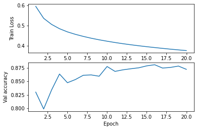

```python
main(model = 'mlp', epochs = 20, batch_size = 1, learning_rate = 0.01, l2_decay = 0,
         hidden_sizes = 200, layers = 1, dropout = 0.3, activation = 'relu', optimizer = 'sgd')
```

**Final test accuracy: 0.8634**

### Learning rate = 0.1

```
Training epoch 1
Training loss: 2.2961
Valid acc: 0.1493
Training epoch 2
Training loss: 2.2643
Valid acc: 0.1406
Training epoch 3
Training loss: 2.2554
Valid acc: 0.1713
Training epoch 4
Training loss: 2.2435
Valid acc: 0.1654
Training epoch 5
Training loss: 2.2416
Valid acc: 0.1651
Training epoch 6
Training loss: 2.2397
Valid acc: 0.1613
Training epoch 7
Training loss: 2.2352
Valid acc: 0.1626
Training epoch 8
Training loss: 2.2372
Valid acc: 0.1388
Training epoch 9
Training loss: 2.2382
Valid acc: 0.1387
Training epoch 10
Training loss: 2.2399
Valid acc: 0.1643
Training epoch 11
Training loss: 2.2401
Valid acc: 0.1458
Training epoch 12
Training loss: 2.2400
Valid acc: 0.1499
Training epoch 13
Training loss: 2.2389
Valid acc: 0.1717
Training epoch 14
Training loss: 2.2378
Valid acc: 0.1581
Training epoch 15
Training loss: 2.2374
Valid acc: 0.1512
Training epoch 16
Training loss: 2.2374
Valid acc: 0.1488
Training epoch 17
Training loss: 2.2379
Valid acc: 0.1485
Training epoch 18
Training loss: 2.2382
Valid acc: 0.1695
Training epoch 19
Training loss: 2.2377
Valid acc: 0.1616
Training epoch 20
Training loss: 2.2389
Valid acc: 0.1479
Final Test acc: 0.1477
```

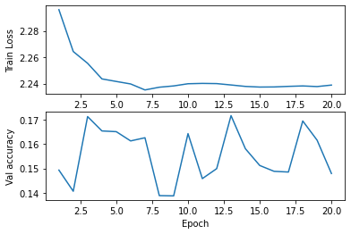

```python
main(model = 'mlp', epochs = 20, batch_size = 1, learning_rate = 0.1, l2_decay = 0,
         hidden_sizes = 200, layers = 1, dropout = 0.3, activation = 'relu', optimizer = 'sgd')
```

**Final test accuracy: 0.1477**

### Hidden size = 100

```
Training epoch 1
Training loss: 0.6246
Valid acc: 0.8071
Training epoch 2
Training loss: 0.5643
Valid acc: 0.8400
Training epoch 3
Training loss: 0.5330
Valid acc: 0.8532
Training epoch 4
Training loss: 0.5125
Valid acc: 0.8495
Training epoch 5
Training loss: 0.4970
Valid acc: 0.8609
Training epoch 6
Training loss: 0.4844
Valid acc: 0.8641
Training epoch 7
Training loss: 0.4736
Valid acc: 0.8511
Training epoch 8
Training loss: 0.4649
Valid acc: 0.8634
Training epoch 9
Training loss: 0.4573
Valid acc: 0.8632
Training epoch 10
Training loss: 0.4502
Valid acc: 0.8641
Training epoch 11
Training loss: 0.4447
Valid acc: 0.8690
Training epoch 12
Training loss: 0.4395
Valid acc: 0.8488
Training epoch 13
Training loss: 0.4343
Valid acc: 0.8732
Training epoch 14
Training loss: 0.4297
Valid acc: 0.8710
Training epoch 15
Training loss: 0.4254
Valid acc: 0.8688
Training epoch 16
Training loss: 0.4212
Valid acc: 0.8628
Training epoch 17
Training loss: 0.4173
Valid acc: 0.8611
Training epoch 18
Training loss: 0.4135
Valid acc: 0.8688
Training epoch 19
Training loss: 0.4100
Valid acc: 0.8594
Training epoch 20
Training loss: 0.4066
Valid acc: 0.8682
Final Test acc: 0.8608
```

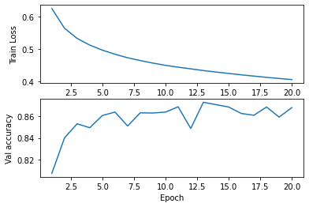

```python
main(model = 'mlp', epochs = 20, batch_size = 1, learning_rate = 0.01, l2_decay = 0,
         hidden_sizes = 100, layers = 1, dropout = 0.3, activation = 'relu', optimizer = 'sgd')
```

**Final test accuracy: 0.8608**

### Dropout = 0.5

```
Training epoch 1
Training loss: 0.7004
Valid acc: 0.8231
Training epoch 2
Training loss: 0.6377
Valid acc: 0.8316
Training epoch 3
Training loss: 0.6051
Valid acc: 0.8354
Training epoch 4
Training loss: 0.5846
Valid acc: 0.8539
Training epoch 5
Training loss: 0.5683
Valid acc: 0.8424
Training epoch 6
Training loss: 0.5552
Valid acc: 0.8540
Training epoch 7
Training loss: 0.5444
Valid acc: 0.8483
Training epoch 8
Training loss: 0.5354
Valid acc: 0.8579
Training epoch 9
Training loss: 0.5278
Valid acc: 0.8640
Training epoch 10
Training loss: 0.5209
Valid acc: 0.8478
Training epoch 11
Training loss: 0.5145
Valid acc: 0.8587
Training epoch 12
Training loss: 0.5088
Valid acc: 0.8587
Training epoch 13
Training loss: 0.5034
Valid acc: 0.8598
Training epoch 14
Training loss: 0.4988
Valid acc: 0.8572
Training epoch 15
Training loss: 0.4945
Valid acc: 0.8665
Training epoch 16
Training loss: 0.4906
Valid acc: 0.8690
Training epoch 17
Training loss: 0.4870
Valid acc: 0.8705
Training epoch 18
Training loss: 0.4835
Valid acc: 0.8639
Training epoch 19
Training loss: 0.4800
Valid acc: 0.8611
Training epoch 20
Training loss: 0.4768
Valid acc: 0.8561
Final Test acc: 0.8507
```

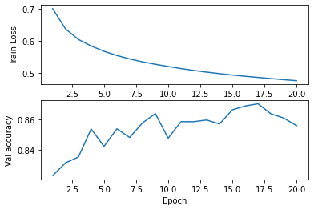

```python
main(model = 'mlp', epochs = 20, batch_size = 1, learning_rate = 0.01, l2_decay = 0,
         hidden_sizes = 200, layers = 1, dropout = 0.5, activation = 'relu', optimizer = 'sgd')
```

**Final test accuracy: 0.8507**

### Activation function Tanh

```
Training epoch 1
Training loss: 0.6316
Valid acc: 0.8327
Training epoch 2
Training loss: 0.5959
Valid acc: 0.7686
Training epoch 3
Training loss: 0.5794
Valid acc: 0.8324
Training epoch 4
Training loss: 0.5683
Valid acc: 0.8497
Training epoch 5
Training loss: 0.5597
Valid acc: 0.8219
Training epoch 6
Training loss: 0.5541
Valid acc: 0.8088
Training epoch 7
Training loss: 0.5490
Valid acc: 0.8417
Training epoch 8
Training loss: 0.5447
Valid acc: 0.8581
Training epoch 9
Training loss: 0.5415
Valid acc: 0.8598
Training epoch 10
Training loss: 0.5381
Valid acc: 0.8518
Training epoch 11
Training loss: 0.5356
Valid acc: 0.8463
Training epoch 12
Training loss: 0.5327
Valid acc: 0.8535
Training epoch 13
Training loss: 0.5298
Valid acc: 0.8444
Training epoch 14
Training loss: 0.5275
Valid acc: 0.8532
Training epoch 15
Training loss: 0.5250
Valid acc: 0.8612
Training epoch 16
Training loss: 0.5226
Valid acc: 0.8495
Training epoch 17
Training loss: 0.5207
Valid acc: 0.8371
Training epoch 18
Training loss: 0.5189
Valid acc: 0.8335
Training epoch 19
Training loss: 0.5173
Valid acc: 0.8662
Training epoch 20
Training loss: 0.5155
Valid acc: 0.8529
Final Test acc: 0.8452
```

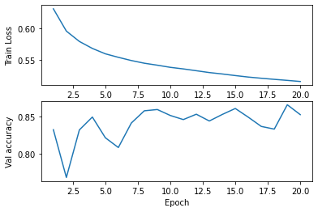

```python
main(model = 'mlp', epochs = 20, batch_size = 1, learning_rate = 0.01, l2_decay = 0,
         hidden_sizes = 200, layers = 1, dropout = 0.3, activation = 'tanh', optimizer = 'sgd')
```

**Final test accuracy: 0.8452**

### Optimizer ADAM

```
Training epoch 1
Training loss: 1.7486
Valid acc: 0.4533
Training epoch 2
Training loss: 1.7674
Valid acc: 0.4544
Training epoch 3
Training loss: 1.7692
Valid acc: 0.4703
Training epoch 4
Training loss: 1.7716
Valid acc: 0.4815
Training epoch 5
Training loss: 1.7967
Valid acc: 0.5105
Training epoch 6
Training loss: 1.8110
Valid acc: 0.4909
Training epoch 7
Training loss: 1.8116
Valid acc: 0.4337
Training epoch 8
Training loss: 1.8155
Valid acc: 0.4649
Training epoch 9
Training loss: 1.8164
Valid acc: 0.4673
Training epoch 10
Training loss: 1.8229
Valid acc: 0.5147
Training epoch 11
Training loss: 1.8203
Valid acc: 0.4876
Training epoch 12
Training loss: 1.8192
Valid acc: 0.5165
Training epoch 13
Training loss: 1.8182
Valid acc: 0.4150
Training epoch 14
Training loss: 1.8107
Valid acc: 0.4643
Training epoch 15
Training loss: 1.8152
Valid acc: 0.5271
Training epoch 16
Training loss: 1.8113
Valid acc: 0.5441
Training epoch 17
Training loss: 1.8089
Valid acc: 0.5141
Training epoch 18
Training loss: 1.8045
Valid acc: 0.5440
Training epoch 19
Training loss: 1.7998
Valid acc: 0.5025
Training epoch 20
Training loss: 1.8053
Valid acc: 0.5021
Final Test acc: 0.5032
```

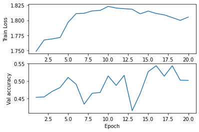

```python
main(model = 'mlp', epochs = 20, batch_size = 1, learning_rate = 0.01, l2_decay = 0,
         hidden_sizes = 200, layers = 1, dropout = 0.3, activation = 'relu', optimizer = 'adam')
```

**Final test accuracy: 0.5032**

## (c)

Using the same hyperparameters as in Table 1, increase the model to `2 and 3 layers`. Report your best configuration, make similar plots as in the previous question, and report the final test accuracy.

### Layers = 2

```
Training epoch 1
Training loss: 0.6417
Valid acc: 0.8325
Training epoch 2
Training loss: 0.5691
Valid acc: 0.8419
Training epoch 3
Training loss: 0.5332
Valid acc: 0.8432
Training epoch 4
Training loss: 0.5102
Valid acc: 0.8544
Training epoch 5
Training loss: 0.4931
Valid acc: 0.8582
Training epoch 6
Training loss: 0.4796
Valid acc: 0.8654
Training epoch 7
Training loss: 0.4691
Valid acc: 0.8579
Training epoch 8
Training loss: 0.4603
Valid acc: 0.8639
Training epoch 9
Training loss: 0.4525
Valid acc: 0.8646
Training epoch 10
Training loss: 0.4457
Valid acc: 0.8621
Training epoch 11
Training loss: 0.4393
Valid acc: 0.8666
Training epoch 12
Training loss: 0.4337
Valid acc: 0.8676
Training epoch 13
Training loss: 0.4289
Valid acc: 0.8763
Training epoch 14
Training loss: 0.4243
Valid acc: 0.8741
Training epoch 15
Training loss: 0.4200
Valid acc: 0.8578
Training epoch 16
Training loss: 0.4161
Valid acc: 0.8643
Training epoch 17
Training loss: 0.4123
Valid acc: 0.8725
Training epoch 18
Training loss: 0.4088
Valid acc: 0.8731
Training epoch 19
Training loss: 0.4057
Valid acc: 0.8713
Training epoch 20
Training loss: 0.4025
Valid acc: 0.8770
Final Test acc: 0.8711
```

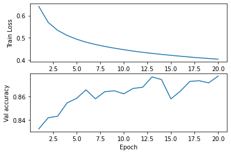

```python
main(model = 'mlp', epochs = 20, batch_size = 1, learning_rate = 0.01, l2_decay = 0,
         hidden_sizes = 200, layers = 2, dropout = 0.3, activation = 'relu', optimizer = 'sgd')
```

**Final test accuracy: 0.8711**

### Layers = 3

```
Training epoch 1
Training loss: 0.7048
Valid acc: 0.8286
Training epoch 2
Training loss: 0.6128
Valid acc: 0.8181
Training epoch 3
Training loss: 0.5704
Valid acc: 0.8454
Training epoch 4
Training loss: 0.5444
Valid acc: 0.8479
Training epoch 5
Training loss: 0.5253
Valid acc: 0.8573
Training epoch 6
Training loss: 0.5107
Valid acc: 0.8599
Training epoch 7
Training loss: 0.4996
Valid acc: 0.8548
Training epoch 8
Training loss: 0.4900
Valid acc: 0.8643
Training epoch 9
Training loss: 0.4816
Valid acc: 0.8542
Training epoch 10
Training loss: 0.4741
Valid acc: 0.8706
Training epoch 11
Training loss: 0.4678
Valid acc: 0.8550
Training epoch 12
Training loss: 0.4621
Valid acc: 0.8681
Training epoch 13
Training loss: 0.4573
Valid acc: 0.8630
Training epoch 14
Training loss: 0.4529
Valid acc: 0.8619
Training epoch 15
Training loss: 0.4490
Valid acc: 0.8656
Training epoch 16
Training loss: 0.4452
Valid acc: 0.8595
Training epoch 17
Training loss: 0.4420
Valid acc: 0.8709
Training epoch 18
Training loss: 0.4388
Valid acc: 0.8671
Training epoch 19
Training loss: 0.4356
Valid acc: 0.8556
Training epoch 20
Training loss: 0.4328
Valid acc: 0.8645
Final Test acc: 0.8622
```

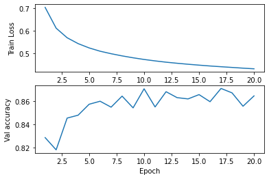

```python
main(model = 'mlp', epochs = 20, batch_size = 1, learning_rate = 0.01, l2_decay = 0,
         hidden_sizes = 200, layers = 3, dropout = 0.3, activation = 'relu', optimizer = 'sgd')
```

**Final test accuracy: 0.8622**